# Weight Lifting Exercises

Amom Mendes

July 2 2016

### Prediction Assignment: How well are people doing exercises?

This document describes the prediction project of Practical Machine Learning course from Cousera. Here we need to predict the quality of exercises done by some volunteers.

The dataset were collect through body sensors that recorded the body movements when these people were doing exercises (unilateral dumbbell biceps curl) “correctly” and “incorrectly”. Correct exercises were labeled as “Class A” exercises and incorrect exercises were labeled as “Class B” to “Class E”, representing common mistakes when doing unilateral dumbbel biceps curl.

#### **Exploring data**

```r
#Libraries
library (ggplot2)
library (caret)
## To download data
#train<-read.csv ("https://d396qusza40orc.cloudfront.net/predmachlearn/pml-training.csv")
#test<- read.csv("https://d396qusza40orc.cloudfront.net/predmachlearn/pml-testing.csv")

# Openning from my local disk

data<- read.csv ('./train.csv', h=T, row.names = 1, na.strings = c('#DIV/0!', 'NA'))
inTrain<- createDataPartition(y=data$classe, p=.7,list=F)

train<- data[inTrain,]
test<- data[-inTrain,]

validation<- read.csv("./test.csv", h=T,row.names = 1, na.strings = c('#DIV/0!', 'NA'))
```

The training data downloaded were divided to cross validation and model selection in two subset: train and test. The original test data were user as validation dataset.

#### **Preprocessing data**

My approach to pre-processing data were simple. I just removed features that had 95% of missing data.

```r
# Function to list columns with more than 95% of values with NA values.

missInt<- function (dt){
    int<- NA
    for (i in 1:ncol(dt)){
        if (mean (is.na(dt[,i]))> .95){
            int[i]<- TRUE} else{int[i]<-FALSE}
    }

    return (which (int==F))
}
missInt(validation)==missInt(train)
```

```
##  [1] TRUE TRUE TRUE TRUE TRUE TRUE TRUE TRUE TRUE TRUE TRUE TRUE TRUE TRUE
## [15] TRUE TRUE TRUE TRUE TRUE TRUE TRUE TRUE TRUE TRUE TRUE TRUE TRUE TRUE
## [29] TRUE TRUE TRUE TRUE TRUE TRUE TRUE TRUE TRUE TRUE TRUE TRUE TRUE TRUE
## [43] TRUE TRUE TRUE TRUE TRUE TRUE TRUE TRUE TRUE TRUE TRUE TRUE TRUE TRUE
## [57] TRUE TRUE TRUE TRUE
```

```r
del<-missInt(train)

train<- train[,del]
train<- train [,-(1:7)]

test<- test[,del]
test<- test[,-(1:7)]

validation<- validation[,del]
validation<- validation[,-(1:7)]
```

#### **Modelling**

I constructed three models:

1 - Boosting model

2 - Random Forest

3 - Stacked Model (with prediction of other two models)

```r
library (caret)
set.seed (33226)
ctrl<- trainControl(method='cv', number=4, verboseIter = F) # Defining some parameters to control models

modGBM<-  train (classe~., data=train, method='gbm', trControl=ctrl )
modRF<-   train (classe~., data=train, method='rf', ntree=99,
        trControl=ctrl) # I reduced the number of threes because
                        #computational power in my local machine

pred2<-predict (modGBM, test)
pred3<-predict (modRF, test)

combMod<- data.frame (pred2,pred3,classe=test$classe)

modSTK<- train (classe~., method='rf', trControl=ctrl, ntree=99, data=combMod)
```

#### Assessing the models

```r
predGBM<-predict (modGBM, test)
predRF<-predict (modRF, test)
predSTK<-predict (modSTK, test)
```

Boosting model: 96.19

Random Forest model: 99.32

Stacked model: 99.354

Random Forest and Stacked model seem to be the acuracy. Probably because them use the same algorithm, but would be necessary to control for some overfitting, probably due to number of predictors and correlation between them. However, because of time I will continue to this mdoel to make predictions.

How are the most important variables?

```r
varImp (modRF)
```

```
## rf variable importance
##
##   only 20 most important variables shown (out of 52)
##
##                      Overall
## roll_belt            100.000
## pitch_forearm         60.319
## yaw_belt              53.238
## magnet_dumbbell_z     45.152
## roll_forearm          44.060
## magnet_dumbbell_y     43.930
## pitch_belt            41.603
## accel_dumbbell_y      23.511
## magnet_dumbbell_x     17.450
## roll_dumbbell         17.134
## magnet_belt_z         15.474
## total_accel_dumbbell  14.777
## accel_forearm_x       14.722
## magnet_forearm_z      14.696
## accel_dumbbell_z      13.887
## accel_belt_z          13.324
## magnet_belt_y         12.865
## gyros_belt_z          12.250
## yaw_arm               10.185
## magnet_belt_x          9.311
```

Lets plot some of them:

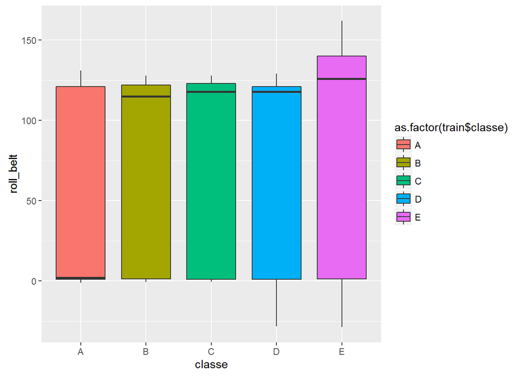

```r
qplot (x=classe, y=roll_belt, data=train, geom = 'boxplot',
       fill=as.factor (train$classe))
```

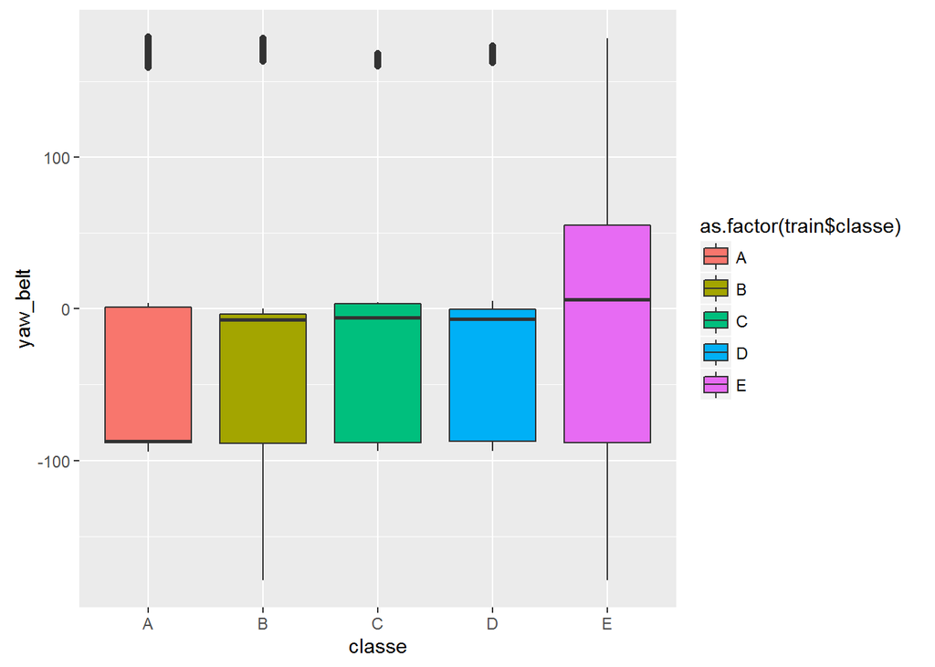

```r
qplot (x=classe, y=yaw_belt, data=train, geom = 'boxplot',
       fill=as.factor (train$classe))
```

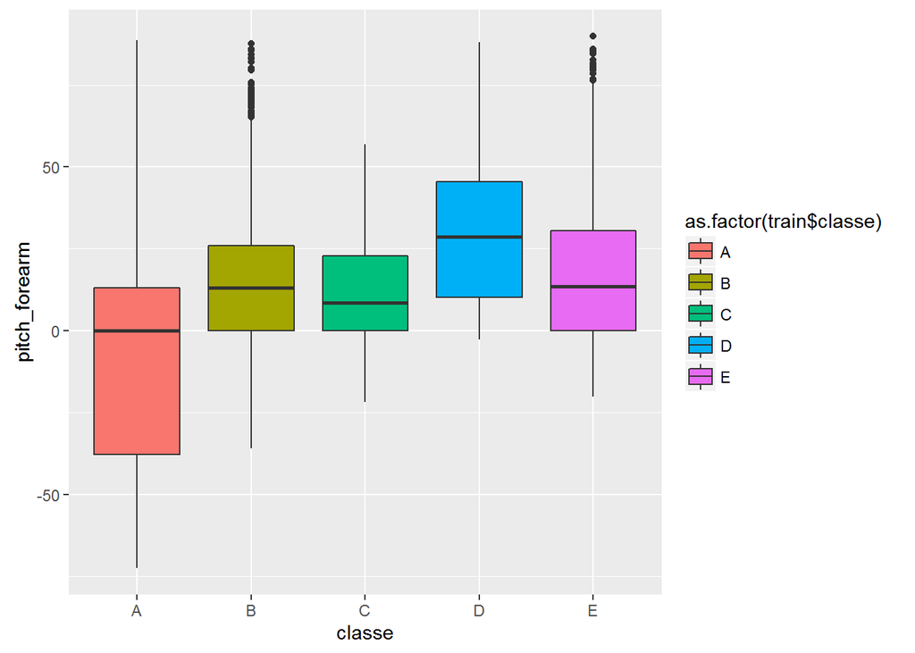

```r
qplot (x=classe, y=pitch_forearm, data=train, geom = 'boxplot',
       fill=as.factor (train$classe))
```

#### Model Predictions

```r
predValidation<- predict (modRF, validation)
data.frame(Id=1:20, Prediction=predValidation)
```

```
##    Id Prediction
## 1   1          B
## 2   2          A
## 3   3          B
## 4   4          A
## 5   5          A
## 6   6          E
## 7   7          D
## 8   8          B
## 9   9          A
## 10 10          A
## 11 11          B
## 12 12          C
## 13 13          B
## 14 14          A
## 15 15          E
## 16 16          E
## 17 17          A
## 18 18          B
## 19 19          B
## 20 20          B
```